# 14 Functions

In the past chapters, we have used functions that came with base R or were included in one of the packages that were installed: `mean()`, `sd()`, `rnorm()`, `pnorm()`, `dplyr::mutate()`, `gglot2::ggplot()`, … . As these functions are build in R or in one of the many packages, you don’t need to write the function code each and every time you use them. In other words, you don’t have to write the full code to calculate the mean if you need the mean, but you can call `mean` to perform this calculation. This shortens the code and avoids mistakes. Using base R’s functions as well as the functions in the packages we introduced and all other packages available on CRAN, R allows you to do a very wide range of tasks. However, sometimes, you will not find a function that fits your needs. This is where you might want to write your own function. In addition, you can use functions to automate tasks that you need to perform regularly. Doing so, you avoid that you have to rewrite your code to do the same calculation of execute a specific task. In general, if you are copy pasting code more than once, it is often preferable to write your code in a function. Usually, after every “paste” of a copies code block, you will have to change parts in the block, e.g. a reference to a variable or a data structure. Doing so, every time you can make little mistakes that are often very difficult to spot. In other words, with every “paste” you risk loosing time searching for that little typo that causes the error in your code. With a function, you avoid these types of errors.

This chapter shows how you can write your own function. In the previous chapters, we used anonymous function, e.g. `function(x) {x + 1}`, or, using shorthand `\(x) {x + 1}`. There is little difference between an anonymous function and a named function as we will introduce them here: they don’t have a name and because of this, they are not saved and can not be reused in subsequent parts of your code. However, as far as coding is concerned, they are very similar to named functions.

As we will use {dplyr}, let’s first load this package

```r
library(tidyverse)
```

## 14.1 The function syntax

To create a function, you use the following basic template:

```r
do_something <- function(arguments) {

  body: what the function does with the arguments
}
```

In this template, using `function()` directive, you create the function `to_something`. The formal arguments of this function are included `function(arguments)`. The body of the function includes the code that R needs to execute. If you want to use this function, you can call it using `do_something(arguments)`.

As far as the name is concerned (`do_something`), there are little limitations on the choice of the name. However, usually, the name is a verb that tells you what the function does. Recall for instance the {dplyr} “verbs”: `mutate`, `filter`, `summarize` or `arrange`. Similarly, other packages often used verbs, e.g. {lubridate}‘s `make_datetime()`, {stringr}’s `str_remove()`, `str_extract` or `str_glue` or {forcats}’ `fct_reorder` or `fct_recode`. If you use a noun, if that noun is very descriptive and unambiguous, e.g. `mean`, `sd`, `max`, … .

The formal arguments, or the `formals` of the function are the variables in the function definition that are passed on to the body of the function. A function can have as many arguments as is necessary. Two ore more formal arguments are separated by a comma. They are included between the parenthesis in the function definition. Formal arguments are named, e.g. `x`, `y`, `mean`, `option`, … . If you call the function, you assign values to these arguments. You can do so in two ways: by matching by name or by matching by position. In the former case, you refer to the name and add a value. For instance, using `rnorm()` you specify the name of the arguments `n`, `mean` and `sd`: `rnorm(n = 1, mean = 10, sd = 25)`. The some holds for function that you create. If your function includes, e.g. `do_something <- function(x, y)` then you will include the values of these arguments in the function call: `do_something(x = 2, y = 5)`. The second way to assign values to the arguments is by position. Using `do_something(2, 5)`, R assigns the value of 2 to the first argument and 5 to the second argument. For instance, using `rnorm(1, 10, 5)`, R assigns the value of 1 to `n`, the value of 10 to the second argument `mean` and 5 to the third argument `sd`. In case you refer to the names to assign values to the arguments, the order in which you do so doesn’t matter. For positional matching, this is not the case: here the order matters as R assign the first value to the first argument, the second to the second argument, … .

The body of the function includes the code that you want to execute. This code is includes in curly braces and is intended two spaces. R executes the code line by line. The body includes the code and also defines “what” the function returns. With respect to the last part, a function always returns one R object, a vector, a matrix or array, a list or data frame or even a function. In general, without explicit return statement, a function returns the output from the last expression in the body of the function.

### 14.1.1 Illustration 1: the function `add_one`

Let’s illustrate this template with a simple function, `add_one`:

```r
add_one <- function(x) {

  x + 1

}
```

The function’s name if `add_one`. There is one formal argument, `x`. The body of the function includes the code that R will execute if you call this function. Here, this code is short and includes only one line: add one to x or `x + 1`. As this is the only expression in the body, this will also be the output of this function. The function `add_one()` is now defined in R. If you type `add` in the console, the function now appears in the suggestions. If you select that function, R also shows the arguments. In this case, there is only one: `x`. You can see the function `add_one` the environment pane.

Let’s assign the value of 5 to the formal argument `x`. There are two ways of doing so. First, via name matching:

```r
add_one(x = 5)
```

```
[1] 6
```

or positional matching:

```r
add_one(5)
```

```
[1] 6
```

The function returns 6. To use this value in subsequent parts of your code, you need to assign the return value of the function to a variable. Here, R will returns the output of `x + 1`. With respect to the arguments of `add_one()`, this means that you can include all values and data structures that allow R to add one to `x`, e.g.

- a value

```r
add_one(x = 5)
```

```
[1] 6
```

```r
class(add_one(x = 5))
```

```
[1] "numeric"
```

- a vector

```r
add_one(1:10)
```

```
 [1]  2  3  4  5  6  7  8  9 10 11
```

```r
class(add_one(1:10))
```

```
[1] "numeric"
```

- a matrix

```r
mat1 <- matrix(c(1:10, 101:110), nrow = 10, ncol = 2)

add_one(mat1)
```

```
      [,1] [,2]
 [1,]    2  102
 [2,]    3  103
 [3,]    4  104
 [4,]    5  105
 [5,]    6  106
 [6,]    7  107
 [7,]    8  108
 [8,]    9  109
 [9,]   10  110
[10,]   11  111
```

```r
class(add_one(mat1))
```

```
[1] "matrix" "array"
```

- a data frame

```r
df1 <- data.frame(
  A = 1:10,
  B = 21:30
)

add_one(df1)
```

```
    A  B
1   2 22
2   3 23
3   4 24
4   5 25
5   6 26
6   7 27
7   8 28
8   9 29
9  10 30
10 11 31
```

```r
class(add_one(df1))
```

```
[1] "data.frame"
```

- or a function

```r
add_one(add_one(x = 5))
```

```
[1] 7
```

Note that in the latter case, the function `add_one()` is nested in the function `add_one()`. The inner function returns `add_one(n = 5)` or 6. The is the input of the outer `add_one()` function. This function now returns `add_one(6)` or 7.

You can use this function on other functions, e.g.

```r
apply(mat1, 2, add_one)
```

```
      [,1] [,2]
 [1,]    2  102
 [2,]    3  103
 [3,]    4  104
 [4,]    5  105
 [5,]    6  106
 [6,]    7  107
 [7,]    8  108
 [8,]    9  109
 [9,]   10  110
[10,]   11  111
```

or

```r
list1 <- list(
  C = 1:10,
  D = 21:30
)

lapply(list1, add_one)
```

```
$C
 [1]  2  3  4  5  6  7  8  9 10 11

$D
 [1] 22 23 24 25 26 27 28 29 30 31
```

Last, recall that the pipe operator `|>` puts the value on its left hand side as the first argument of the function on its right hand side. Here, with only one formal argument, this means that you can leave the argument open:

```r
100 |> add_one()
```

```
[1] 101
```

These last two examples and the function definition of `add_one()` allow to highlight the similarities with the anonymous functions. Recall that we used these in e.g. Chapter 13. As a matter of fact, we used the anonymous function `function(x) {x + 1}` or, using shorthand, `\(x) {x + 1}` to illustrate `apply()`. As you can see, with the exception of the name, `add_one` the anonymous function shares a lot of similarities with the named function. The body in both the is same and, if you are not using the shorthand version, so is the `function()` directive. However, as the anonymous function is not an object in R, you can not reuse it in subsequent parts of your code. Using a named function, reuse if possible.

### 14.1.2 Illustration 2: the function `final_value`

As a second example, let’s define a function that calculate the value of a value of a bond after one year with an interest rate equal to 5% (0.05). For every 100 in that bond, the bond returns 100 + 5% of 100 = 100 + 0.05 * 100 = 100 * (1 + 0.05), or, more in general, for every 100 invested in that bond and with an interest rate equal to i, the bond returns after one year:
$$100 * (1 + i)^1$$

If the bond runs for two years the bond’s value after two years equals the value after one year plus the interest rate on that value earned in the second year: (100 + 5% of 100) + 5% of 105 = (100 + 5% of 100) + 5% of (100 + 5% of 100) = 100 (1 + 0.05)^2. More in general, with an interest rate equal to i, the bond’s value after two years is

$$100 * (1 + i)^2$$

After three years, the value of the bond equals

$$100 * (1 + i)^3$$
and after n years, the value is

$$100 * (1 + i)^n$$

Let’s build a function that allows to calculate the value for any investment (i.e. not necessarily equal to 100), for any interest rate (i.e. with i not necessarily equal to 5%) and for varying investment periods (i.e. for varying n). Here, this function as three arguments: x, the initial value of the investment, i, the interest rate on the bond and n the number of years in the investment horizon. The body of the function calculates the value of the bond after n years: `x * (1 + i)^n`. Let’s use the name `final_value()` for this function. We now have all the elements we need to create the function `final_value()`:

```r
final_value <- function(x, i, n) {

  x * (1 + i)^n

}
```

In the environment pane, you can see that this function is now defined. If you type `fin` in the console, R will include `final_value` as one of the suggestions. We can no call this function to calculate the value of a bond. Matching the arguments by name to calculate the value of 100 after one year and with an interest rate of 5%:

```r
final_value(x = 100, i = 0.05, n = 1)
```

```
[1] 105
```

As we matched the arguments by name, we don’t have to follow their order:

```r
final_value(i = 0.05, n = 1, x = 100)
```

```
[1] 105
```

Matching the arguments by position need to respect the order:

```r
final_value(100, 0.05, 1)
```

```
[1] 105
```

If you don’t do so, the function will not return the correct final value

```r
final_value(1, 0.05, 100)
```

```
[1] 131.5013
```

Here, you calculate the value of an investment equal to 1 at an interest rate of 5% and for a period of 100 years.

As with `add_one`, `final_value` allows you to include a vector of investments as values for the formal arguments, e.g.

```r
final_value(x = 100:109, i = 0.05, n = 2)
```

```
 [1] 110.2500 111.3525 112.4550 113.5575 114.6600 115.7625 116.8650 117.9675
 [9] 119.0700 120.1725
```

calculates the value of the bond after two years using an interest rate equal to 5% for 10 values of x: 100, 101, …, 109;

```r
final_value(x = 100, i = seq(from = 0.01, to = 0.10, by = 0.01), n = 2)
```

```
 [1] 102.01 104.04 106.09 108.16 110.25 112.36 114.49 116.64 118.81 121.00
```

calculates the value of the bond with an initial investment of 100, for 2 years but using interest rates starting at 1% and ending at 10% in steps of 1%-point and

```r
final_value(x = 100, i = 0.05, n = 1:10)
```

```
 [1] 105.0000 110.2500 115.7625 121.5506 127.6282 134.0096 140.7100 147.7455
 [9] 155.1328 162.8895
```

calculates the value of the bond with an initial investment of 100, an interest rate of 5% but for periods starting at 1 year and ending at 10 years in steps of 1 year. However, you can not add various values for different arguments at the same time

```r
final_value(x = 100:109, seq(from = 0.01, to = 0.10, by = 0.01), n = 1)
```

```
 [1] 101.00 103.02 105.06 107.12 109.20 111.30 113.42 115.56 117.72 119.90
```

```r
c(100, 200) * c(2, 5)
```

```
[1]  200 1000
```

Using the `|>` operator, you can “pipe” values for `x` in the function:

```r
1000 |> final_value(0.05, 2)
```

```
[1] 1102.5
```

To pipe an interest rate of investment horizon into the function, you have to use a named argument with the place holder `_` (Chapter 1)

```r
0.05 |> final_value(100, i = _, 1)
```

```
[1] 105
```

## 14.2 The function environment and scoping rules

If you run a function, R creates a special environment for that function. A variables that you create inside a function only exist within that function (the environment defined by the function). To illustrate, let’s create an variant of the function `final_value()` and define `final_value2()` as:

```r
final_value2 <- function(x, i, n) {

  y <- x * (1 + i)^n
  y <- y^2

}
```

Note that `final_value2()` only differs from `final_value()` because it assigns the outcome of the calculation to a variable `y` and then calculates the square of `y`? If you now run the function, it doesn’t return anything:

```r
final_value2(x = 100, i = 0.05, n = 1)
```

This shouldn’t come as a surprise as you assign the value of the calculation to a variable `y`. If you assign a value to a name, R never returns the value. For instance, here

```r
z <- 10 + 20
```

R creates the variable `z`, assigns the value of 30 but doesn’t return the value of 30 in the console. In the environment pane, you can see that variable `z` as well as its value 30. However, if you run

```r
final_value2(x = 100, i = 0.05, n = 1)
```

You don’t see the variable `y` in the environment pane. If you use the value of `y` outside of the function,

```r
final_value2(x = 100, i = 0.05, n = 1)
y
```

```
Error:
! object 'y' not found
```

R shows an error as it can not find the value of `y` even if you just called the function `final_value2()` where `y` was assigned the value of the bond. The reason for this is that R creates a new environment every time the function is called. The objects that are created when the function is called only exist as within that environment and do not have an impact on values in other environments, e.g. the global environment (the environment pane). Applied to `final_value2()`: R creates the object `y` within that function, but forgets about it as the function is executed. As a result, R shows the error `y not found`.

What happens if you already had a value for `y` defined outside of the function? For instance, suppose that you have the following two lines of code:

```r
y <- 50
final_value2(x = 100, i = 0.05, n = 1)
```

Here, `y` is first assigned the value of 50. We know that the function `final_value2()` will first assign the value `100 * (1 + 0.05)^1` or `105` to `y` and second, will assign the value of `y^2` to `y`. If we now ask for the value of `y`, R returns

```r
y <- 50
final_value2(x = 100, i = 0.05, n = 1)
y
```

```
[1] 50
```

the value of 50, i.e. the value that was assigned to `y` in the first line. The reason lies in the fact that R creates a separate environment as the function executes. Within that environment, the value of `y` stands on its own, or, it “masks” the object with the same name outside of the function. This is due to the fact that R uses lexical scoping rules: R first looks for the value of an object in the function’s environment, then in any enclosing environment (e.g. the global environment), then in a package, … . Here, as R finds the value of `y` it needs to compute the square of `y` inside the function `final_value2()`, it doesn’t look for the value of `y` in the global environment. As R “forgets” about the values its creates in a function, the value of `y` in the global environment (50) was never changed as `final_value2()` was executed.

This also means that every time you call the function, the objects that you define within that function don’t exist outside of the function and do not have a value once the function closes. In other words, R forgets the value of `y` permanently.

If you define a variable outside of the function (in the global environment), R will first search in body of the function to see if it can find the associated value. If that is not the case, R will search for a value in the global environment. In other words, using `final_value()` and assigning the value of 100 to `x` outside of the function, R will use this value for `x` as it executes the code.

```r
x <- 100

final_value(x, i = 0.05, n = 1)
```

```
[1] 105
```

```r
x
```

```
[1] 100
```

## 14.3 The formal arguments of a function

### 14.3.1 Default values

The function `final_value()` includes 3 formal arguments: `x`, `i` and `n`. If one of these arguments is missing, the function will not return a value:

```r
final_value(x = 100, i = 0.05)
```

```
Error in `final_value()`:
! argument "n" is missing, with no default
```

One way to avoid this is to include default values. With default values, R will use these values unless the function call includes others. To do so, you add the default values for all formal arguments where you want to define a default value in the definition of the function. For instance, suppose you want to include a default value for the interest rate `i`equal to 5% and a default value for the investment period `n` of 1 year without definining a default value for the initial investment `x`, you add these values in the definition:

```r
final_value <- function(x, i = 0.05, n = 1) {

  x * (1 + i)^n

}
```

The environment pane shows these default values. In addition if you type `fin` in the console and select the function `final_value()` R now shows the default values. With these values, you can now call the function `final_value()` with one argument: the value for `x`:

```r
final_value(1000)
```

```
[1] 1050
```

To calculate the final value using another interest rate, you can specify its value:

```r
final_value(1000, 0.075)
```

```
[1] 1075
```

As you can see, R now uses the value of 7.5% for the interest rate while it keeps the value for the investment horizon `n`. Changing the investment horizon `n` while keeping the default value for the interest rate requires a name match as

```r
final_value(1000, 10)
```

```
[1] 11000
```

returns the value of the bond after one year with with an interest rate equal to 1000% and multiplies the investment with (1 + 10) ^1. In other words, if you want to calculate the final value for an investment horizon of 10 years using the interest rate’s default value, you have to name the argument:

```r
final_value(1000, n = 10)
```

```
[1] 1628.895
```

### 14.3.2 Lazy evaluation

Arguments in the function are evaluated as they are needed in the body of the function. This is also referred to as lazy evaluation. One of the consequences is that R will execute a function even if one of its arguments is never used. To illustrate, let’s consider the following example.

```r
f_lazy <- function(x, y) {

  2 * x

}
```

The function `f_lazy()` has two formal arguments: `x` and `y`. However, the function never uses the second argument, `y`. Neither of these arguments has a default value. R will execute the function without a warning or error as long as you include a value for `x`. Leaving out a value for `y` will show the expected result:

```r
f_lazy(x = 2)
```

```
[1] 4
```

This also holds in case you don’t refer to the name of the argument as the value of 2 will be matched with `x` by position:

```r
f_lazy(2)
```

```
[1] 4
```

You will also get the expected result if you add a value for `y`:

```r
f_lazy(x = 2, y = 10)
```

```
[1] 4
```

### 14.3.3 Free variables

To illustrate a free variable, consider this function `f_free()`:

```r
f_free <- function(x, y) {

  (x + y) / z
}
```

```r
f_free(x = 10, y = 20)
```

```
[1] 1
```

If there is a value assigned to `z`, R will use that value:

```r
z <- 5
f_free(x = 10, y = 20)
```

```
[1] 6
```

### 14.3.4 Are the arguments correct?

In the body of the function, you can add a check on the values. As an example, for the interest rate, you can use 0.05 as well as 5.00. The first is assumed in the code, the second would return a value, but that final value wouldn’t be correct. To avoid these mistakes, you can add a check: if the interest rate is higher than or equal to e.g. 1 (or 100%), you assume that the interest rate is included as 2% and not as 0.02. Using that assumption, you divide the interest rate value if the argument `i` by 100 is the condition `i >= 1` is met. In addition, you print a warning that this changes was made. You can add this in the body of the function:

```r
final_value <- function(x, i = 0.05, n = 1) {

  if (i >= 1) {
    print(paste("Warning: Interest rate", i, "divided by 100. Interest rate used is", i/100))
    i <- i/100
    }
  x * (1 + i)^n

}
```

If you include e.g. 2 as a value for `i`, the function will now use 0.02 to calculate the final value but will also warn that it didn’t use 2 but divided the interest rate by 100.

```r
final_value(100, i = 2, n = 1)
```

```
[1] "Warning: Interest rate 2 divided by 100. Interest rate used is 0.02"
```

```
[1] 102
```

## 14.4 The return value

A function returns the last line expression that was executed. In `final_value()` - assuming that the interest rate is correct - this is `x * (1 + i)^n`. In addition, a function returns only one data structure. What if you want to show more than the final value but would like to include the initial value as will as the interest rate and investment horizon? To do so, you have to add all values that the function needs to return in a single object and include that object in the last line of your code, e.g

- a (named) vector,

```r
final_value <- function(x, i, n) {
  y <- x * (1 + i)^n
  c("init_value" = x, "final_value" = y)
}
```

which returns

```r
final_value(x = 100, i = 0.05, n = 1)
```

```
 init_value final_value
        100         105
```

- or, e.g. a list

```r
final_value <- function(x, i, n) {
  y <- x * (1 + i)^n
  list(init_value = x, final_value = y)
}
```

which allows to store heterogeneous results

```r
final_value(x = 100, i = 0.05, n = 1)
```

```
$init_value
[1] 100

$final_value
[1] 105
```

As you define the type of the result, your functions become more predictable: if you set the return value to be a list, the function will return a list.

A function returns the last expression. The `return()` statement allows you to be explicit on what the function will return. In the parentheses of this statement, you add the expression that the function will return. Adding this statement in the previous definition:

```r
final_value <- function(x, i, n) {
  y <- x * (1 + i)^n
  return( c("init_value" = x, "final_value" = y))
}
```

shows that the function will return a named vector with two values: `x` and `y`.

## 14.5 Functions, data frames and the tidyverse

To illustrate, we’ll use an example taken from Wickham, Cetinkaya-Rundel, and Grolemund (2023). Suppose you want to write a function to calculate the means of a variable `mean_var` across groups defined by `group_var`. Using {dplyr}’s `group_by()` and `summarize()`, you could write this function as:

```r
grouped_mean <- function(df, group_var, mean_var) {
  df |>
    group_by(group_var) |>
    summarize(ave_price = mean(mean_var))
}
```

Let’s now use this function to calculate the mean price of diamonds for every level of cut. Here, the `group_var` is `cut` and the variable `mean_var` is price. Using the `grouped_mean()` function:

```r
diamonds |> grouped_mean(cut, price)
```

```
Error in `group_by()`:
! Must group by variables found in `.data`.
✖ Column `group_var` is not found.
```

Here, R returns an error: it can’t find the column `group_var`. The problem is that R looks for the variable `group_var` and that it can not find as it is not included in the diamonds dataset. In other words, you need a way to tell R that it had to look in that data frame to find the variables `cut` and `price`. To do so, you need to embrace the variables in the body of the function between two curly braces: `{ var }` (note the space around `var`). Doing so, R will not use the variable name, but the variable stored in the variable name. Rewriting the `grouped_mean()` function where the `group_var` and `mean_var` are embraced in the body of the function:

```r
grouped_mean <- function(df, group_var, mean_var) {
  df |>
    group_by({{ group_var }}) |>
    summarize(ave_price = mean({{ mean_var }}))
}
```

We can now use this function with the diamonds dataset:

```r
diamonds |> grouped_mean(cut, price)
```

```
# A tibble: 5 × 2
  cut       ave_price
  <ord>         <dbl>
1 Fair          4359.
2 Good          3929.
3 Very Good     3982.
4 Premium       4584.
5 Ideal         3458.
```

As you can see from the result of this function, the function now shows the mean prices per level of cut. As this function returns a data frame, you can use it as part of a flow e.g. as input in a function that create a plot.

If you write a function to produce a graph using {ggplot2}, you also need embracing. For instance, to write a function that returns a point geometry with a mapping of `var1` on the horizontal axis, `var2` on the vertical axis and `var3` on the color aesthetic:

```r
fun_geompoint <- function(df, var1, var2, var3) {
  df |> ggplot(aes(x = {{ var1 }}, y = {{ var2 }}, color = {{ var3 }})) +
    geom_point() +
    theme_minimal()
}
```

Plotting (10%) of the diamonds dataset with `carat` on the horizontal axis, `price` on the vertical axis and `cut` mapped on the color aesthetic:

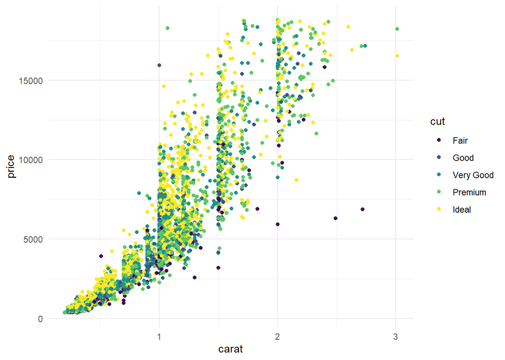

```r
df_sample <- slice_sample(diamonds, prop = 0.10)

fun_geompoint(df_sample, carat, price, cut)
```

The `englue()` function of the R package {rlang} works similar to `glue::glue()`(see Chapter 4) but allows for the use of the double curly braces. Using this function you can add labels to you plot, e.g.:

```r
fun_geompoint <- function(df, var1, var2, var3) {

  title <- rlang::englue("The relation between {{ var1 }} and {{ var2 }} by {{ var3 }}")
  xaxis <- rlang::englue("{{ var1 }}")
  yaxis <- rlang::englue("{{ var2 }}")
  color <- rlang::englue("{{ var3 }}")


  df |> ggplot(aes(x = {{ var1 }}, y = {{ var2 }}, color = {{ var3 }})) +
    geom_point() +
      labs(
      title = title,
      x = stringr::str_to_title(xaxis),
      y = stringr::str_to_title(yaxis),
      color = stringr::str_to_title(color)) +
    theme_minimal()
}
```

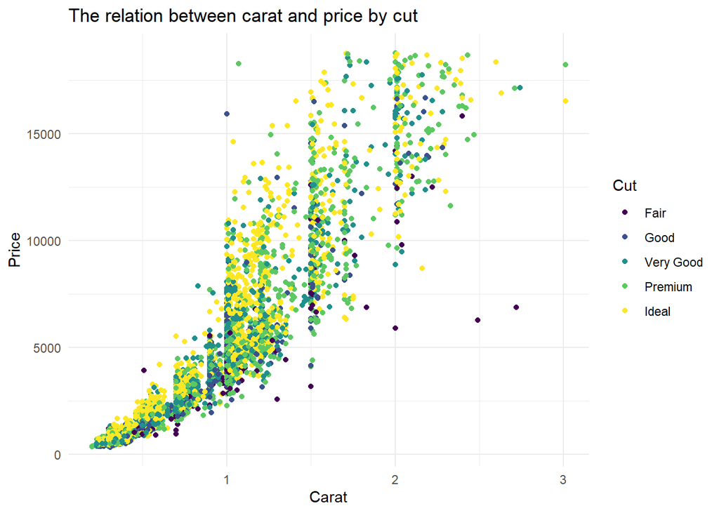

```r
fun_geompoint(df_sample, var1 = carat, var2 = price, var3 = cut)
```

Note that you can add other variables that to include in e.g. the breaks or labels for the axis, … . To do so, you include e.g. the number of breaks as a separate formal argument in the function. This also holds for the theme. You can set the value of a theme using the function directive

```r
theme_yourtheme <- function(){
  theme(
    panel.background = element_rect(fill = "white"),
    axis.line = element.line(color = "grey")
  ... )
}
```

In the arguments of the function you can set, e.g. the font family or font size, a base color, … . After creating your theme function, you can use that function to add lay-out options to your ggplot.

## 14.6 Functions in your code

From these examples, you can see that functions are often a very good way to deal with repetitive tasks: using a function you can load libraries,

```r
fun_load <- function() {
  library(tidyverse)
  library(gt)
  library(gtExtrax)
  library(readxl)
}
```

import data, clean and tidy data using, produce various summary statistics and present them in tables or plots using minimum code. If you save your function in an R file, you can re-use this function other code using the `source()` function. If you save your script with your function in e.g. your `scripts` folder, you can access these function using `source(here::here("scripts", "functions.R"))`. If you add this line in your code, all function in that script are available to use.

Wickham, Hadley, Cetinkaya-Rundel Mine, and Garrett Grolemund. 2023. *R for Data Science: Import, Tidy, Transform, Visualize, and Model Data (2nd Edition)*. Sebastopol, CA: O’Reilly Media.